# Loan Default Analysis and Prediction

Eunice Gong

## Motivation

After going through ACC1701X, Accounting for Decision Makers in school, I was curious about how exactly expected credit loss (ECL) was calculated since it was briefly touched on and its calculations were simplified given that it was an introductory module.

On further research, ECL is often calculated using the formula: ECL = Probablity of Default(PD) * Exposure at Default(EAD) * Loss Given at Default(LGD)

I am interested in determining PD, hence I found a Loan Default Prediction dataset I could work with on from Datacamp, the dataset I am using is “Raw Credit Data” [Loan Default Prediction dataset] (https://app.datacamp.com/learn/courses/credit-risk-modeling-in-python)

Limitations:  
This is a highly simplified dataset on individuals, the calculation of PD for ECL in real life is much more complicated with macroeconomic factors, etc for each company.  
Nonetheless, it still serves as a good practice dataset.

```r
credit_data <- read.csv("cr_loan2.csv")
```

## Initial Data Exploration

```r
str(credit_data)
```

```
## 'data.frame':    32581 obs. of  12 variables:
##  $ person_age                : int  22 21 25 23 24 21 26 24 24 21 ...
##  $ person_income             : int  59000 9600 9600 65500 54400 9900 77100 78956 83000 10000 ...
##  $ person_home_ownership     : chr  "RENT" "OWN" "MORTGAGE" "RENT" ...
##  $ person_emp_length         : int  123 5 1 4 8 2 8 5 8 6 ...
##  $ loan_intent               : chr  "PERSONAL" "EDUCATION" "MEDICAL" "MEDICAL" ...
##  $ loan_grade                : chr  "D" "B" "C" "C" ...
##  $ loan_amnt                 : int  35000 1000 5500 35000 35000 2500 35000 35000 35000 1600 ...
##  $ loan_int_rate             : num  16 11.1 12.9 15.2 14.3 ...
##  $ loan_status               : int  1 0 1 1 1 1 1 1 1 1 ...
##  $ loan_percent_income       : num  0.59 0.1 0.57 0.53 0.55 0.25 0.45 0.44 0.42 0.16 ...
##  $ cb_person_default_on_file : chr  "Y" "N" "N" "N" ...
##  $ cb_person_cred_hist_length: int  3 2 3 2 4 2 3 4 2 3 ...
```

```r
summary(credit_data)
```

```
##    person_age     person_income     person_home_ownership person_emp_length
##  Min.   : 20.00   Min.   :   4000   Length:32581          Min.   :  0.00
##  1st Qu.: 23.00   1st Qu.:  38500   Class :character      1st Qu.:  2.00
##  Median : 26.00   Median :  55000   Mode  :character      Median :  4.00
##  Mean   : 27.73   Mean   :  66075                         Mean   :  4.79
##  3rd Qu.: 30.00   3rd Qu.:  79200                         3rd Qu.:  7.00
##  Max.   :144.00   Max.   :6000000                         Max.   :123.00
##                                                           NA's   :895
##  loan_intent         loan_grade          loan_amnt     loan_int_rate
##  Length:32581       Length:32581       Min.   :  500   Min.   : 5.42
##  Class :character   Class :character   1st Qu.: 5000   1st Qu.: 7.90
##  Mode  :character   Mode  :character   Median : 8000   Median :10.99
##                                        Mean   : 9589   Mean   :11.01
##                                        3rd Qu.:12200   3rd Qu.:13.47
##                                        Max.   :35000   Max.   :23.22
##                                                        NA's   :3116
##   loan_status     loan_percent_income cb_person_default_on_file
##  Min.   :0.0000   Min.   :0.0000      Length:32581
##  1st Qu.:0.0000   1st Qu.:0.0900      Class :character
##  Median :0.0000   Median :0.1500      Mode  :character
##  Mean   :0.2182   Mean   :0.1702
##  3rd Qu.:0.0000   3rd Qu.:0.2300
##  Max.   :1.0000   Max.   :0.8300
##
##  cb_person_cred_hist_length
##  Min.   : 2.000
##  1st Qu.: 3.000
##  Median : 4.000
##  Mean   : 5.804
##  3rd Qu.: 8.000
##  Max.   :30.000
##
```

```r
head(credit_data)
```

```
##   person_age person_income person_home_ownership person_emp_length loan_intent
## 1         22         59000                  RENT               123    PERSONAL
## 2         21          9600                   OWN                 5   EDUCATION
## 3         25          9600              MORTGAGE                 1     MEDICAL
## 4         23         65500                  RENT                 4     MEDICAL
## 5         24         54400                  RENT                 8     MEDICAL
## 6         21          9900                   OWN                 2     VENTURE
##   loan_grade loan_amnt loan_int_rate loan_status loan_percent_income
## 1          D     35000         16.02           1                0.59
## 2          B      1000         11.14           0                0.10
## 3          C      5500         12.87           1                0.57
## 4          C     35000         15.23           1                0.53
## 5          C     35000         14.27           1                0.55
## 6          A      2500          7.14           1                0.25
##   cb_person_default_on_file cb_person_cred_hist_length
## 1                         Y                          3
## 2                         N                          2
## 3                         N                          3
## 4                         N                          2
## 5                         Y                          4
## 6                         N                          2
```

```r
tail(credit_data)
```

```
##       person_age person_income person_home_ownership person_emp_length
## 32576         52         64500                  RENT                 0
## 32577         57         53000              MORTGAGE                 1
## 32578         54        120000              MORTGAGE                 4
## 32579         65         76000                  RENT                 3
## 32580         56        150000              MORTGAGE                 5
## 32581         66         42000                  RENT                 2
##           loan_intent loan_grade loan_amnt loan_int_rate loan_status
## 32576       EDUCATION          B      5000         11.26           0
## 32577        PERSONAL          C      5800         13.16           0
## 32578        PERSONAL          A     17625          7.49           0
## 32579 HOMEIMPROVEMENT          B     35000         10.99           1
## 32580        PERSONAL          B     15000         11.48           0
## 32581         MEDICAL          B      6475          9.99           0
##       loan_percent_income cb_person_default_on_file cb_person_cred_hist_length
## 32576                0.08                         N                         20
## 32577                0.11                         N                         30
## 32578                0.15                         N                         19
## 32579                0.46                         N                         28
## 32580                0.10                         N                         26
## 32581                0.15                         N                         30
```

```r
any(is.na(credit_data))
```

```
## [1] TRUE
```

From str(), we gathered that the structure of the data is as follows:

person_age(integer): Borrower’s age  
person_income(integer): Borrower’s income  
person_home_ownership(character): Borrower’s state of home ownership (rent, own, mortgage)  
person_emp_length(integer): Borrower’s length of employment  
loan_intent(character): Reason for loan  
loan_grade(character): Grade of loan  
loan_amnt(integer): Principal Amount of loan  
loan_int_rate(numeric): Yearly interest that has to be paid on remaining principal  
loan_status(integer): If the loan is defaulted or not (0 = Not default, 1 = default)  
loan_percent_income(numeric): Percentage of loan compared to income  
cb_person_default_on_file(character): If the person defaulted on a loan before  
cb_person_cred_hist_length(integer): Number of years borrower has held the credit for

From summary(), we observe that there are NA values for person_emp_length and loan_int_rate.  
We also observe that max person_age is 144 and max person_emp_length is 123, which is very unlikely because the longest someone has ever lived was till 122 years old. There are outliers in the data possibly caused by errors in data input. We have to perform data cleaning to remove or control for NA values and outliers.

## Data Cleaning

First, we plot a histogram to observe the frequency distribution of person_emp_length

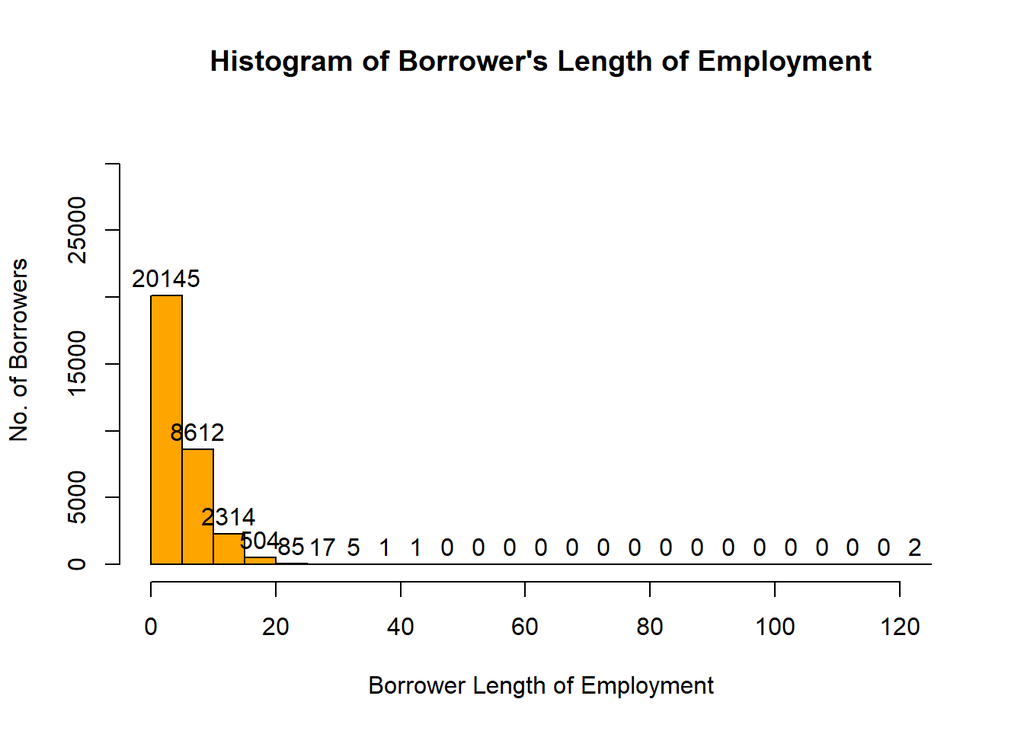

```r
hist(credit_data$person_emp_length,
         main = "Histogram of Borrower's Length of Employment",
           xlab = "Borrower Length of Employment",
           ylab = "No. of Borrowers",
           col = "Orange",
           ylim = c(0,32000),
         labels = TRUE, breaks = 26)
```

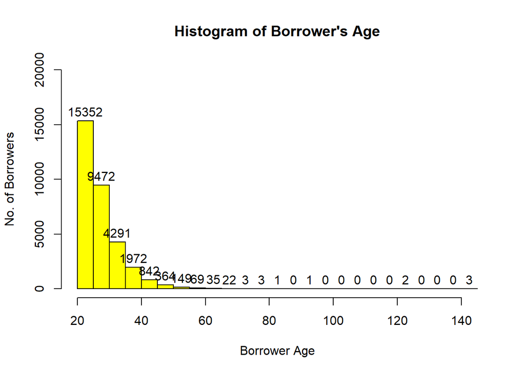

```r
hist(credit_data$person_age,
         main = "Histogram of Borrower's Age",
           xlab = "Borrower Age",
           ylab = "No. of Borrowers",
           col = "Yellow",
           ylim = c(0,20000),
         labels = TRUE, breaks = 26)
```

1. For person_emp_length, the missing data is likely to be missing at random (MAR), since some borrowers with shorter employment length may be less likely to disclose their employment length when applying for the loan as a shorter employment length may reduce their chances of receiving the loan.
2. From the histogram above, we observe that the data is likely to be right-skewed. Hence to address missing values, I will impute median person_emp_length.

However, due to the presence of outliers which may affect the median of person_emp_length, I will remove outliers before imputing missing values. I will set the maximum employment length to be 65.

```r
credit_data_clean1 <- filter(credit_data, credit_data$person_emp_length <= 65 | is.na(person_emp_length)) #removes outliers and preserve NA values
credit_data_cleanm <- filter(credit_data, credit_data$person_emp_length <= 65) #removes outliers and NA values for calculation of median
emp_len_median <- median(credit_data_cleanm$person_emp_length)
credit_data_clean2 <- credit_data_clean1 %>% mutate(person_emp_length = ifelse(is.na(person_emp_length), emp_len_median, person_emp_length)) # replaces NA values with median
```

For loan_int_rate, this should have been set by the loaner. The data might be missing due to errors in data input by employees, missing completely at random (MCAR).

Because there are 3116 observations missing, which makes up roughly 10% of the dataset, replacing NA values with median might skew the data, which is undesirable as loan_int_rate is potentially a crucial variable for determining probability of default, leading to false conclusions.  
Since the dataset is large, and considering the bias by imputation, we chose to remove rows containing NA values. While there is a slight reduction of data size which may lead to a slight bias in our analysis, overall it ensures integrity of the data.

```r
credit_data_clean3 <- filter(credit_data_clean2, !is.na(loan_int_rate))
```

Next, I will remove outliers for person_age. I will set the maximum age to be 100.

```r
credit_data_cleaned <- filter(credit_data_clean3, credit_data_clean3$person_age <= 100)
```

Finally, we plot the histograms again to check if the data has been appropriately cleaned.

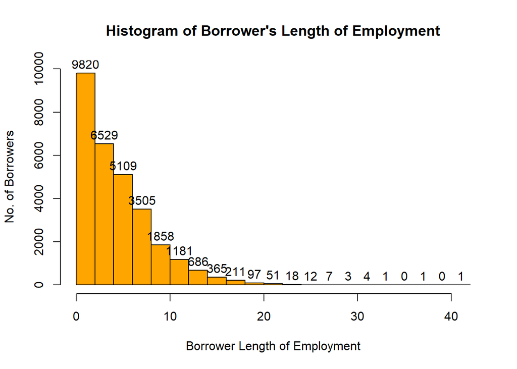

```r
hist(credit_data_cleaned$person_emp_length,
         main = "Histogram of Borrower's Length of Employment",
           xlab = "Borrower Length of Employment",
           ylab = "No. of Borrowers",
           col = "Orange",
           ylim = c(0,10000),
         labels = TRUE, breaks = 26)
```

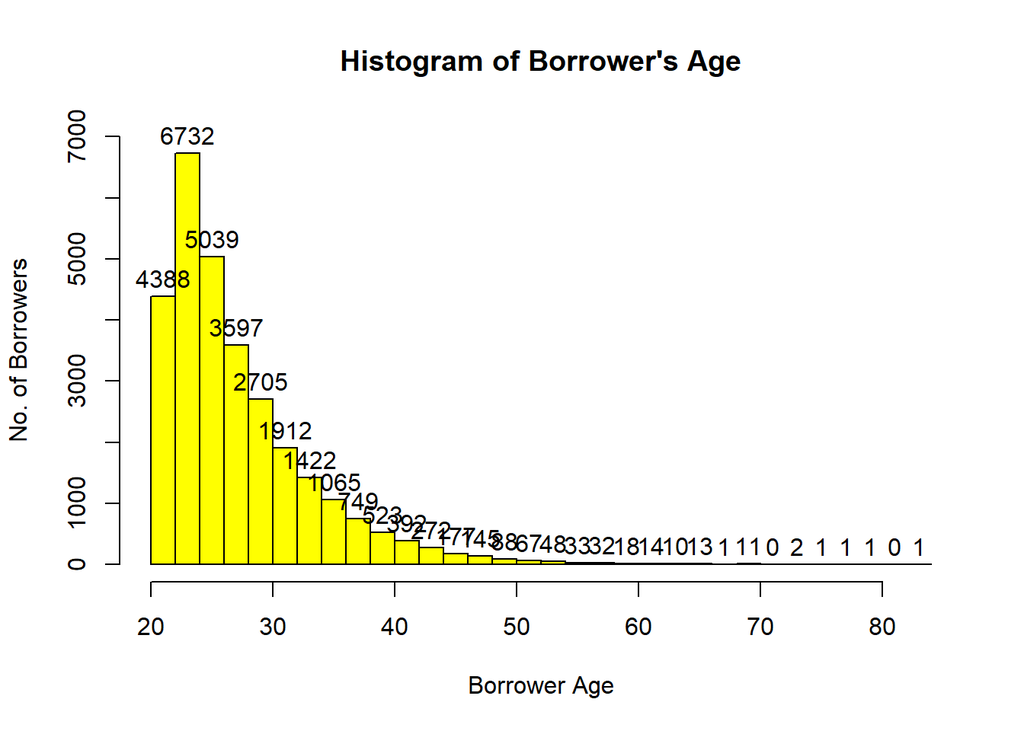

```r
hist(credit_data_cleaned$person_age,
         main = "Histogram of Borrower's Age",
           xlab = "Borrower Age",
           ylab = "No. of Borrowers",
           col = "Yellow",
           ylim = c(0,7000),
         labels = TRUE, breaks = 26)
```

From the above histograms, we observe that most borrowers are between the ages of 20-30 and have been employed for less than 10 years. This seems reasonable most likely because young people would have less savings as they would still be studying or have just started working, and would need to borrow to finance their college fees, apartment fees, and when they start a family.

## Data Visualization

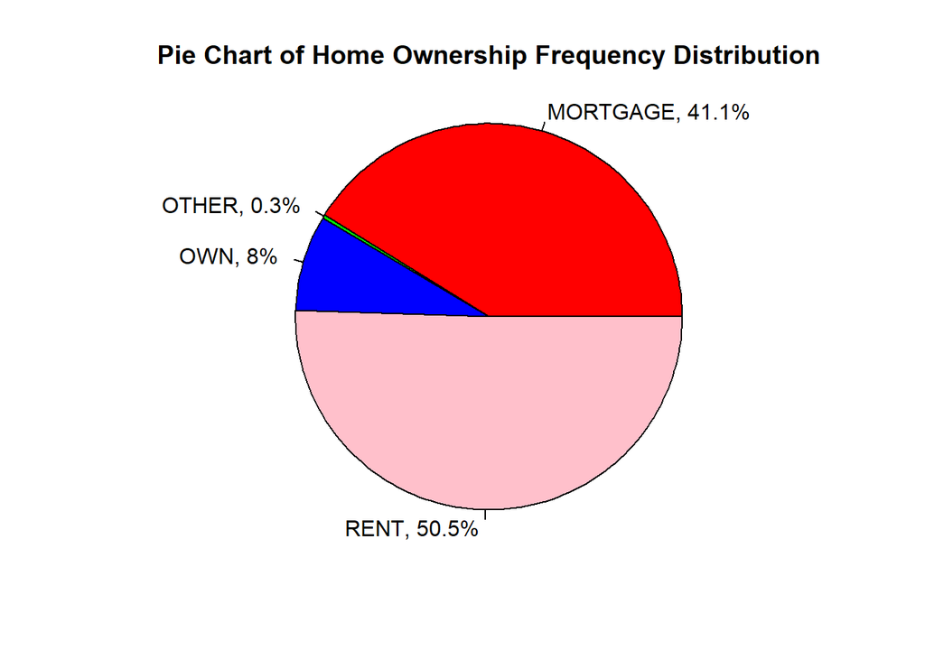

```r
home_ownership_freq <- credit_data_cleaned %>% count(person_home_ownership)
slice_home <- home_ownership_freq$n #n column in House
home_piepercent <- 100*round(home_ownership_freq$n/ sum(home_ownership_freq$n),3 )
label <- paste(home_ownership_freq$person_home_ownership,
               ", ",
               home_piepercent,
               "% ", sep = "")
#label <- paste(label, ",", sep="") default of sep is " "

pie(slice_home, labels = label, col=c("Red", "Green", "Blue", "Pink"), radius = 1 , main ="Pie Chart of Home Ownership Frequency Distribution")
```

From the pie chart, we observe that more than half (50.5%) of the borrowers rent their houses and 41.1% are still paying for mortgage for their houses. This is also reasonable given the young demographics, most would not have the financial ability to own their homes. We also expect people who own their own homes to be more financially stable and hence would be less likely to take out a loan.

```r
rpivotTable(credit_data_cleaned, rows ="loan_status", cols=c("loan_grade","cb_person_default_on_file"),aggregatorName = "Count as Fraction of Columns")
```

[interactive table not shown]

Those who have no prior records of defaulting received either a loan grade of A or B for their current loan. The percentage of those who default on their loans are higher for lower grades.

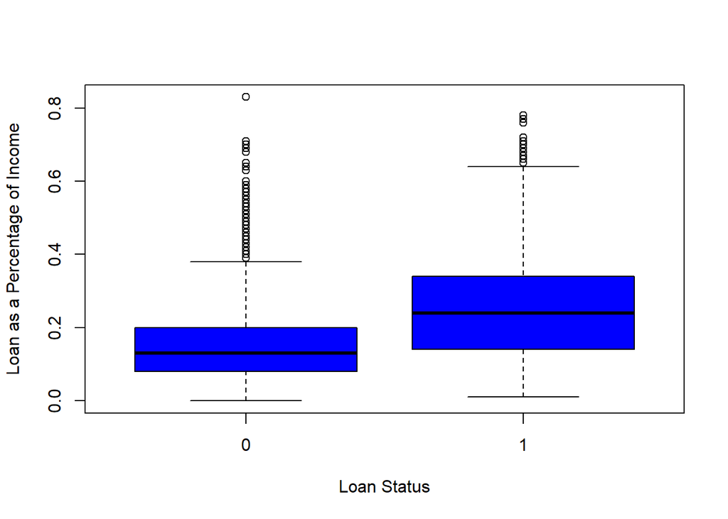

```r
boxplot(credit_data_cleaned$loan_percent_income~credit_data_cleaned$loan_status,
        col = "blue",
        xlab = "Loan Status",
        ylab = "Loan as a Percentage of Income")
```

From the boxplot, we observe that those who have defaulted on their loans generally have a higher loan_percent_income.

```r
credit_intent_percent <- credit_data_cleaned %>% group_by(loan_intent) %>% summarize(total_loans = n(),
  default_loans = sum(loan_status == 1)
)%>%  mutate(percent_of_total_loans = round(total_loans *100 / sum(total_loans),2),
            default_percent = round(default_loans *100 / total_loans,2) )
kable(credit_intent_percent)
```

| loan_intent | total_loans | default_loans | percent_of_total_loans | default_percent |
| --- | --- | --- | --- | --- |
| DEBTCONSOLIDATION | 4703 | 1346 | 15.96 | 28.62 |
| EDUCATION | 5852 | 1011 | 19.86 | 17.28 |
| HOMEIMPROVEMENT | 3290 | 863 | 11.17 | 26.23 |
| MEDICAL | 5451 | 1471 | 18.50 | 26.99 |
| PERSONAL | 5012 | 1009 | 17.01 | 20.13 |
| VENTURE | 5151 | 763 | 17.49 | 14.81 |

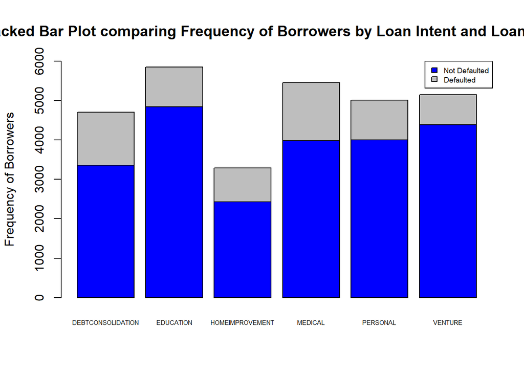

```r
credit_matrix <- credit_data_cleaned %>% group_by(loan_intent, loan_status) %>% tally()
credit_matrix_spread <- credit_matrix %>% spread(key = loan_intent, value = n)

bar_matrix <- as.matrix(credit_matrix_spread[,c(2:7)])
bar_col <- c("Blue", "Grey")
barplot(bar_matrix, col= bar_col, main ="Stacked Bar Plot comparing Frequency of Borrowers by Loan Intent and Loan Status", ylab ="Frequency of Borrowers", ylim = c(0,6000), cex.names = 0.5)
legend("topright", fill = bar_col, legend = c("Not Defaulted", "Defaulted"), cex = 0.6)
```

## Modelling

Observe that loan_percent_income is derived from loan_amount/person_income. Hence these 3 variables are perfectly multicollinear, we have to remove one of them in our model. I have chosen to remove loan_amount.

```r
mod_full <- glm(loan_status ~ person_age + person_income + factor(person_home_ownership) + person_emp_length + factor(loan_intent) + factor(loan_grade) + loan_int_rate + loan_percent_income + factor(cb_person_default_on_file) + cb_person_cred_hist_length, data = credit_data_cleaned, family = "binomial")
summary(mod_full)
```

```
##
## Call:
## glm(formula = loan_status ~ person_age + person_income + factor(person_home_ownership) +
##     person_emp_length + factor(loan_intent) + factor(loan_grade) +
##     loan_int_rate + loan_percent_income + factor(cb_person_default_on_file) +
##     cb_person_cred_hist_length, family = "binomial", data = credit_data_cleaned)
##
## Coefficients:
##                                      Estimate Std. Error z value Pr(>|z|)
## (Intercept)                        -3.240e+00  1.995e-01 -16.244  < 2e-16 ***
## person_age                         -1.118e-02  6.138e-03  -1.821 0.068552 .
## person_income                      -1.281e-05  7.159e-07 -17.897  < 2e-16 ***
## factor(person_home_ownership)OTHER  5.017e-01  2.994e-01   1.676 0.093814 .
## factor(person_home_ownership)OWN   -1.518e+00  1.026e-01 -14.799  < 2e-16 ***
## factor(person_home_ownership)RENT   8.886e-01  4.204e-02  21.136  < 2e-16 ***
## person_emp_length                  -1.810e-02  5.036e-03  -3.594 0.000326 ***
## factor(loan_intent)EDUCATION       -8.466e-01  5.900e-02 -14.348  < 2e-16 ***
## factor(loan_intent)HOMEIMPROVEMENT  6.374e-02  6.593e-02   0.967 0.333667
## factor(loan_intent)MEDICAL         -1.819e-01  5.596e-02  -3.250 0.001153 **
## factor(loan_intent)PERSONAL        -6.098e-01  6.031e-02 -10.111  < 2e-16 ***
## factor(loan_intent)VENTURE         -1.099e+00  6.418e-02 -17.127  < 2e-16 ***
## factor(loan_grade)B                 1.094e-01  7.989e-02   1.370 0.170714
## factor(loan_grade)C                 2.968e-01  1.211e-01   2.451 0.014243 *
## factor(loan_grade)D                 2.340e+00  1.528e-01  15.318  < 2e-16 ***
## factor(loan_grade)E                 2.504e+00  1.932e-01  12.961  < 2e-16 ***
## factor(loan_grade)F                 2.799e+00  2.722e-01  10.282  < 2e-16 ***
## factor(loan_grade)G                 6.684e+00  1.152e+00   5.802 6.54e-09 ***
## loan_int_rate                       6.634e-02  1.759e-02   3.771 0.000163 ***
## loan_percent_income                 8.371e+00  1.776e-01  47.143  < 2e-16 ***
## factor(cb_person_default_on_file)Y  1.245e-02  5.231e-02   0.238 0.811869
## cb_person_cred_hist_length          1.049e-02  9.298e-03   1.129 0.259028
## ---
## Signif. codes:  0 '***' 0.001 '**' 0.01 '*' 0.05 '.' 0.1 ' ' 1
##
## (Dispersion parameter for binomial family taken to be 1)
##
##     Null deviance: 30999  on 29458  degrees of freedom
## Residual deviance: 20325  on 29437  degrees of freedom
## AIC: 20369
##
## Number of Fisher Scoring iterations: 6
```

```r
mod_init <- glm(loan_status ~ 1, data = credit_data_cleaned)
mod_forward <- step(mod_init, scope = formula(mod_full), direction = 'forward')
```

```
## Start:  AIC=31622.11
## loan_status ~ 1
##
##                                     Df Deviance   AIC
## + factor(loan_grade)                 6   4162.2 25967
## + loan_percent_income                1   4320.4 27056
## + loan_int_rate                      1   4478.6 28115
## + factor(person_home_ownership)      3   4746.4 29830
## + factor(cb_person_default_on_file)  1   4881.6 30654
## + person_income                      1   4896.9 30746
## + factor(loan_intent)                5   4963.6 31153
## + person_emp_length                  1   5007.7 31405
## + person_age                         1   5042.9 31611
## + cb_person_cred_hist_length         1   5044.1 31618
## <none>                                   5045.1 31622
##
## Step:  AIC=25967.21
## loan_status ~ factor(loan_grade)
##
##                                     Df Deviance   AIC
## + loan_percent_income                1   3601.9 21710
## + factor(person_home_ownership)      3   3939.6 24354
## + person_income                      1   4011.4 24882
## + factor(loan_intent)                5   4090.0 25461
## + person_emp_length                  1   4134.4 25772
## + person_age                         1   4158.3 25942
## + cb_person_cred_hist_length         1   4160.2 25955
## + loan_int_rate                      1   4160.5 25957
## <none>                                   4162.2 25967
## + factor(cb_person_default_on_file)  1   4162.0 25968
##
## Step:  AIC=21710.12
## loan_status ~ factor(loan_grade) + loan_percent_income
##
##                                     Df Deviance   AIC
## + factor(person_home_ownership)      3   3429.8 20273
## + factor(loan_intent)                5   3530.2 21128
## + person_income                      1   3573.2 21476
## + person_emp_length                  1   3586.1 21583
## + loan_int_rate                      1   3600.9 21704
```

[output cut: 68 more lines]

```
##     loan_int_rate + person_age
##
##                                     Df Deviance   AIC
## + cb_person_cred_hist_length         1   3356.2 19654
## <none>                                   3356.5 19655
## + factor(cb_person_default_on_file)  1   3356.5 19657
##
## Step:  AIC=19654.33
## loan_status ~ factor(loan_grade) + loan_percent_income + factor(person_home_ownership) +
##     factor(loan_intent) + person_income + person_emp_length +
##     loan_int_rate + person_age + cb_person_cred_hist_length
##
##                                     Df Deviance   AIC
## <none>                                   3356.2 19654
## + factor(cb_person_default_on_file)  1   3356.2 19656
```

```r
summary(mod_forward)
```

```
##
## Call:
## glm(formula = loan_status ~ factor(loan_grade) + loan_percent_income +
##     factor(person_home_ownership) + factor(loan_intent) + person_income +
##     person_emp_length + loan_int_rate + person_age + cb_person_cred_hist_length,
##     data = credit_data_cleaned)
##
## Coefficients:
##                                      Estimate Std. Error t value Pr(>|t|)
## (Intercept)                        -2.978e-02  2.116e-02  -1.407 0.159395
## factor(loan_grade)B                 5.812e-03  8.675e-03   0.670 0.502878
## factor(loan_grade)C                 3.911e-02  1.323e-02   2.957 0.003112 **
## factor(loan_grade)D                 3.908e-01  1.711e-02  22.845  < 2e-16 ***
## factor(loan_grade)E                 4.212e-01  2.235e-02  18.842  < 2e-16 ***
## factor(loan_grade)F                 4.598e-01  3.213e-02  14.313  < 2e-16 ***
## factor(loan_grade)G                 7.086e-01  5.085e-02  13.935  < 2e-16 ***
## loan_percent_income                 1.194e+00  1.955e-02  61.073  < 2e-16 ***
## factor(person_home_ownership)OTHER  5.721e-02  3.500e-02   1.634 0.102177
## factor(person_home_ownership)OWN   -1.007e-01  7.740e-03 -13.009  < 2e-16 ***
## factor(person_home_ownership)RENT   1.137e-01  4.415e-03  25.763  < 2e-16 ***
## factor(loan_intent)EDUCATION       -9.951e-02  6.643e-03 -14.980  < 2e-16 ***
## factor(loan_intent)HOMEIMPROVEMENT -5.967e-03  7.722e-03  -0.773 0.439630
## factor(loan_intent)MEDICAL         -1.800e-02  6.742e-03  -2.670 0.007584 **
## factor(loan_intent)PERSONAL        -6.988e-02  6.877e-03 -10.161  < 2e-16 ***
## factor(loan_intent)VENTURE         -1.136e-01  6.872e-03 -16.532  < 2e-16 ***
## person_income                      -4.181e-07  4.176e-08 -10.012  < 2e-16 ***
## person_emp_length                  -1.763e-03  5.195e-04  -3.393 0.000692 ***
## loan_int_rate                       4.278e-03  1.955e-03   2.188 0.028691 *
## person_age                         -1.432e-03  6.707e-04  -2.135 0.032789 *
## cb_person_cred_hist_length          1.640e-03  1.018e-03   1.611 0.107152
## ---
## Signif. codes:  0 '***' 0.001 '**' 0.01 '*' 0.05 '.' 0.1 ' ' 1
##
## (Dispersion parameter for gaussian family taken to be 0.1140085)
##
##     Null deviance: 5045.1  on 29458  degrees of freedom
## Residual deviance: 3356.2  on 29438  degrees of freedom
## AIC: 19654
##
## Number of Fisher Scoring iterations: 2
```

The final model is mod_forward.

To use the model to predict probability of default for an individual, you can use the code predicted <- predict(mod_forward, newdata = new_data, type = “response”), where new_data is the data frame containing the required information: loan_grade, loan_percent_income, person_home_ownership, loan_intent, person_income, person_emp_length, loan_int_rate, person_age, cb_person_cred_hist_length

```r
set.seed(123)

sample_index <- sample(1:nrow(credit_data_cleaned), size = 0.2 * nrow(credit_data_cleaned))
test_data <- credit_data_cleaned[sample_index, ]

predicted <- predict(mod_forward, newdata = test_data, type = "response")
actual <- factor(test_data$loan_status, levels = c(0, 1))
predicted_binary <- factor(ifelse(predicted > 0.5, 1, 0), levels = c(0, 1))

confusionMatrix(data = predicted_binary, reference = actual,positive = "1")
```

```
## Confusion Matrix and Statistics
##
##           Reference
## Prediction    0    1
##          0 4359  670
##          1  198  664
##
##                Accuracy : 0.8527
##                  95% CI : (0.8433, 0.8616)
##     No Information Rate : 0.7736
##     P-Value [Acc > NIR] : < 2.2e-16
##
##                   Kappa : 0.5193
##
##  Mcnemar's Test P-Value : < 2.2e-16
##
##             Sensitivity : 0.4978
##             Specificity : 0.9566
##          Pos Pred Value : 0.7703
##          Neg Pred Value : 0.8668
##              Prevalence : 0.2264
##          Detection Rate : 0.1127
##    Detection Prevalence : 0.1463
##       Balanced Accuracy : 0.7272
##
##        'Positive' Class : 1
##
```

## Note

This in a work in progress.  
I will be adding on better prediction models in the future when I learn about them in my free time